# Beyond MLR Lab 3: Treatment effects across laboratories

Model answers · Week 2

# A wound-healing experiment

Five laboratories compare a **standard treatment** with an **experimental treatment** in a simulated wound-healing experiment. Each laboratory uses 20 independent cell-culture plates and randomly assigns 10 plates to each treatment. Each plate is measured once, 48 hours after treatment. The outcome is the **percentage of the original wound area that has closed**. Higher values indicate more closure.

This is a randomized block design, with laboratory as the blocking factor. The experimental unit is the cell-culture plate. The dataset contains 100 observations simulated for teaching.

Our question is: **How do the estimated treatment effects vary across laboratories, and how much improvement is estimated within each laboratory?** We treat the five laboratories as fixed and focus on treatment comparisons within these laboratories.

By the end of this lab, you should be able to explore an interaction, fit and interpret a fixed interaction model, estimate simple treatment effects, and assess the model assumptions.

**NoteWorking through the lab**

Run the code in order in an R script, and record your answers to the questions. The lab page shows the code; you generate the results yourself.

# Setup and data

Create a `week2` folder with a `data` subfolder. Download the wound-healing dataset and save it as `week2/data/wound_healing_week2.csv`. Save your analysis script as `lab3.R` inside `week2` and set `week2` as your working directory, following the instructions in Lab 1.

We use `ggplot2` for figures, `dplyr` for summaries, and `emmeans` to calculate estimated marginal means and comparisons between them. Use `pak` as introduced in Lab 1. If it asks whether to proceed, confirm the installation and wait for it to finish.

```r
library(pak)
pkg_install(c("ggplot2", "dplyr", "emmeans"))
```

Load the analysis packages in each new R session.

```r
library(ggplot2)
library(dplyr)
library(emmeans)
```

Read the data and specify the order of the factor levels.

```r
wound <- read.csv("data/wound_healing_week2.csv")
wound$treatment <- factor(wound$treatment,
                           levels = c("Standard", "Experimental"))
wound$laboratory <- factor(wound$laboratory)

head(wound)
str(wound)
table(wound$laboratory, wound$treatment)
```

Each row represents one plate. The variables are:

| Variable | Meaning |
| --- | --- |
| `plate_id` | Unique identifier for the plate |
| `laboratory` | Laboratory A, B, C, D, or E |
| `treatment` | Standard or Experimental |
| `closure` | Wound closure after 48 hours, as a percentage of the original area |

Differences between treatment means are measured in **percentage points**. For example, a mean closure of 60% compared with 50% is a difference of 10 percentage points.

**ImportantQuestion 1**

Check the allocation table. How many plates receive each treatment in each laboratory? What is the experimental unit, and why are treatment comparisons made within laboratories?

**TipModel answer 1**

Number of plates in each laboratory and treatment group

|  | Standard | Experimental |
| --- | --- | --- |
| Laboratory A | 10 | 10 |
| Laboratory B | 10 | 10 |
| Laboratory C | 10 | 10 |
| Laboratory D | 10 | 10 |
| Laboratory E | 10 | 10 |

Each laboratory assigns 10 plates to standard treatment and 10 to experimental treatment. There are 20 plates per laboratory, 50 per treatment, and 100 in total.

The experimental unit is the **cell-culture plate**, because treatment is assigned to individual plates and each plate is measured once. Randomization within laboratories allows treatments to be compared among plates handled in the same laboratory. These comparisons account for differences in baseline closure between laboratories. Equal allocation gives both treatments the same representation in every laboratory.

# Explore treatment differences across laboratories

Calculate the number of plates, mean closure, and standard deviation for each treatment within each laboratory.

```r
laboratory_summary <- wound |>
  group_by(laboratory, treatment) |>
  summarise(
    n = n(),
    mean_closure = mean(closure),
    sd_closure = sd(closure),
    .groups = "drop"
  )
laboratory_summary
```

Create an **interaction plot** of these observed means. Laboratories are on the horizontal axis. Each line represents one treatment and connects its means across laboratories.

```r
interaction_plot <- ggplot(
  laboratory_summary,
  aes(x = laboratory, y = mean_closure,
      color = treatment, group = treatment)
) +
  geom_line(linewidth = 0.9) +
  geom_point(size = 3) +
  scale_color_manual(values = c(Standard = "#173F48",
                                Experimental = "#D58A3D")) +
  labs(x = "Laboratory", y = "Mean wound closure (%)",
       color = "Treatment") +
  theme_minimal(base_size = 13) +
  theme(legend.position = "top")

interaction_plot
```

The vertical gap between the experimental and standard lines at each laboratory is its observed treatment difference. Parallel lines would indicate equal observed differences. Varying gaps suggest that the effects may vary. Sampling variation also contributes to differences between the observed means.

**ImportantQuestion 2**

Does the plot suggest a similar treatment effect in all five laboratories? Identify laboratories with relatively large or small observed treatment differences. Use the summary table to distinguish differences in mean closure from variation among plates.

**TipModel answer 2**

Observed wound closure by laboratory and treatment

| Laboratory | Treatment | Plates | Mean closure (%) | SD (percentage points) |
| --- | --- | --- | --- | --- |
| Laboratory A | Standard | 10 | 42.15 | 8.40 |
| Laboratory A | Experimental | 10 | 49.17 | 9.57 |
| Laboratory B | Standard | 10 | 52.38 | 7.95 |
| Laboratory B | Experimental | 10 | 54.69 | 4.71 |
| Laboratory C | Standard | 10 | 45.51 | 8.12 |
| Laboratory C | Experimental | 10 | 66.17 | 10.88 |
| Laboratory D | Standard | 10 | 56.56 | 8.90 |
| Laboratory D | Experimental | 10 | 55.23 | 7.39 |
| Laboratory E | Standard | 10 | 52.57 | 6.56 |
| Laboratory E | Experimental | 10 | 70.33 | 6.61 |

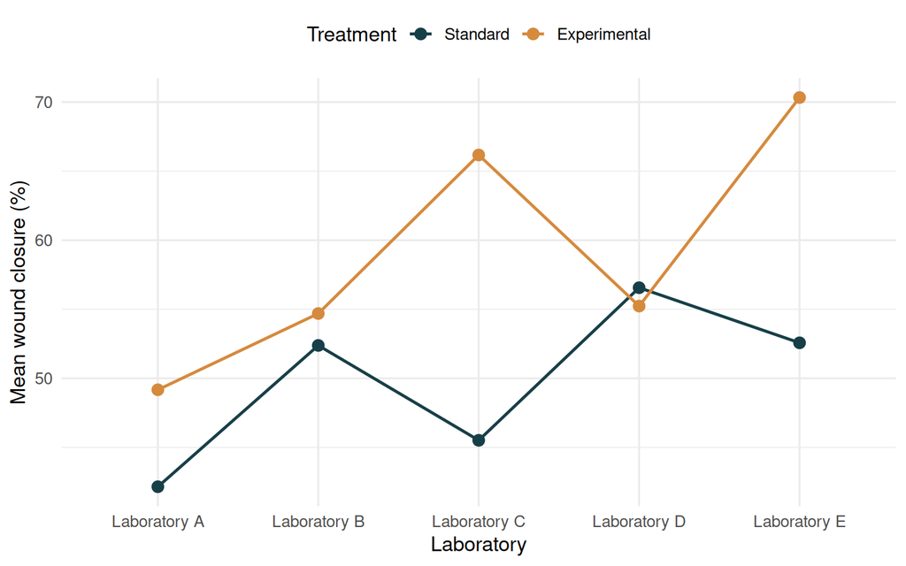

The gaps between the lines vary substantially. The observed experimental-minus-standard differences are 7.02 percentage points in A, 2.31 in B, 20.66 in C, −1.33 in D, and 17.76 in E. Laboratories C and E have the largest observed improvements; B has a small positive difference, and D has a small negative difference. Laboratory A lies between these groups.

The standard-treatment means also vary, from 42.15% in A to 56.56% in D. These describe differences in baseline mean closure. The treatment differences describe how much the mean changes between treatments within each laboratory.

The within-group standard deviations range from 4.71 to 10.88 percentage points. They describe variation among individual plates receiving the same treatment in the same laboratory. The nonparallel lines suggest an interaction, with sampling variation contributing to the observed differences.